# 항공사의 고객 만족도를 높이는 요인에 대하여

## 1. 서론

### 분석을 하게된 동기나 배경

- 이번 학기 학습한 로지스틱 회귀를, 방대한 양의 BI(Buisness Intelligence) 데이터에 직접 적용을 해봄으로서, 반응변수(항공사 서비스 만족 여부에 대한 오즈)에 설명변수가 어떤 영향을 미치는지를 파악하기 위해 본 주제를 선택.
- 더 나아가 로지스틱 회귀가 가진 예측 및 분류기로서의 특성 또한, 해당 분석을 통하여 직접 확인하고자 함.

### 수집한 자료의 출처 및 성격

- “US Airline Passenger Satisfaction”
- 수집한 자료는 2015년 미국의 항공사를 이용한 12만 명 이상의 고객들의 서비스 만족도에 대한 데이터로서, 항공사와 고객의 이름은 기업정보 및 개인정보의 이유로 식별할 수 없음.

### 변수

- Satisfaction : 고객 만족 여부 / 명목형 (1 = 만족 / 0 = 중립 또는 불만족)
- Gender : 고객의 성별 / 명목형 (Female = 여성 / Male = 남성)
- Customer.Type : 고객 유형 / 명목형 (disloyal Customer = 충성도가 낮은 고객 / Loyal Customer = 충성도가 높은 고객 )
- Age : 고객의 연령 / 수치형
- Type.of.Travel : 고객의 탑승 목적 / 명목형 (Personal Travel = 개인적 목적 / Business Travel = 비즈니스 목적)
- Class : 좌석 유형 / 명목형 (Business = 비즈니스 석 / Eco Plus = 이코노미 플러스 / Eco = 이코노미)
- Flight.Distance : 비행 거리(노트) / 수치형
- Seat.comfort : 착석감 / 순서형 (0 ~ 5)
- Dep.Arr.time.convenient : 도착/출발 편리성 / 순서형 (0 ~ 5)
- Food.and.drink : 기내식 만족도 / 순서형 (0 ~ 5)
- Gate.location : 게이트 위치 만족도 / 순서형 (0 ~ 5)
- Inflight.entertainment : 기내 오락 만족도 / 순서형 (0 ~ 5)
- Online.support : 온라인 지원 만족도 / 순서형 (0 ~ 5)
- Ease.of.Online.booking : 온라인 예약 용이성 / 순서형 (0 ~ 5)
- On.board.service : 기내 서비스 만족도 / 순서형 (0 ~ 5)
- Leg.room.service : 레그룸 만족도 / 순서형 (0 ~ 5)
- Baggage.handling : 수화물 처리 만족도 / 순서형 (0 ~ 5)
- Checkin.service : 체크인 서비스 만족도 / 순서형 (0 ~ 5)
- Cleanliness : 청결도 / 순서형 (0 ~ 5)
- Online.boarding : 온라인 탑승 만족도 / 순서형 (0 ~ 5)
- Departure.Delay : 출발 지연 시간(분) / 수치형
- Arrival.Delay : 도착 지연 시간(분) / 수치형

### 분석을 수행하기 전 예상하는 결과

- 고객의 성별, 고객의 연령, 고객의 탑승 목적, 비행 거리별 항공사의 서비스 만족에 대한 오즈의 차이는 없거나, 작을 것이다.
- 충성도가 높은 고객이, 그렇지 않은 고객보다 항공사의 서비스에 만족하는 경향이 있을 것이다.
- ‘이코노미 -> 이코노미 플러스 -> 비즈니스’의 좌석 유형 순으로 항공사의 서비스 만족에 대한 오즈가 높을 것이다.
- 모든 순서형 변수는 증가할수록, 항공사의 서비스 만족에 대한 오즈가 높아질 것이다.
- 도착 지연 시간과 출발 지연 시간이 증가할수록, 항공사의 서비스 만족에 대한 오즈가 낮아질 것이다.

## 2. 본론

### 데이터 전처리

```r
setwd("C:/Users/이찬솔")
data <- read.csv("US Airline Passenger Satisfaction.csv", header = T)
sum(is.na(data)) # 결측값 확인
```

```
## [1] 393
```

```r
data <- na.omit(data) # 결측값 제거
sum(is.na(data))
```

```
## [1] 0
```

- 분석에 앞서, 데이터內 393개의 결측값의 존재를 확인, 본 프로젝트는 결측값을 별도의 값으로 대체하지 않고, 제외하여 분석하는 완전분석법에 따라 진행하기로 결정.

```r
data$Satisfaction <- as.factor(data$Satisfaction)
data$Gender <- as.factor(data$Gender)
data$Customer.Type <- as.factor(data$Customer.Type)
data$Class <- as.factor(data$Class)
data$Type.of.Travel <- as.factor(data$Type.of.Travel)
dim(data)
```

```
## [1] 129487     22
```

- as.factor()함수를 통해 명목형 변수들을 설정.
- 모형의 간결함과, 해석의 용이성을 위하여, 본 분석에서는 순서형 변수들을 양적변수로 간주하여 모형을 적합하기로 결정.
- 전처리를 마무리한 데이터의 차원은 129487개의 행과, 22개의 열로 구성됨을 확인.

### 적합할 모형 설정

- 모형 설정에 앞서 이 데이터는 총 21개의 많은 설명변수들을 포함하는 만큼, 양적변수들간의 상관계수 및 VIF값을 파악하여 높은 상관관계 여부를 파악할 필요가 있다.

```r
quan_var <- cbind(data[,4], data[,7:22]) ; colnames(quan_var) <- c(3, 6:21)
cor <- cor(quan_var)
tail(round(cor,3), 5)
```

```
##         3     6      7     8      9     10     11     12     13     14    15
## 17  0.032 0.003  0.041 0.063  0.012 -0.032  0.224  0.207  0.138  0.251 0.168
## 18 -0.019 0.009  0.109 0.067  0.033 -0.002  0.109  0.096  0.418  0.551 0.412
## 19  0.038 0.010  0.130 0.000  0.014 -0.003  0.356  0.670  0.684  0.140 0.113
## 20 -0.009 0.112 -0.024 0.004 -0.013  0.004 -0.030 -0.034 -0.037 -0.038 0.004
## 21 -0.011 0.110 -0.026 0.003 -0.015  0.004 -0.033 -0.036 -0.040 -0.041 0.000
##        16     17     18     19     20     21
## 17  0.241  1.000  0.242  0.184 -0.021 -0.024
## 18  0.632  0.242  1.000  0.106 -0.062 -0.067
## 19  0.112  0.184  0.106  1.000 -0.020 -0.022
## 20 -0.010 -0.021 -0.062 -0.020  1.000  0.965
## 21 -0.014 -0.024 -0.067 -0.022  0.965  1.000
```

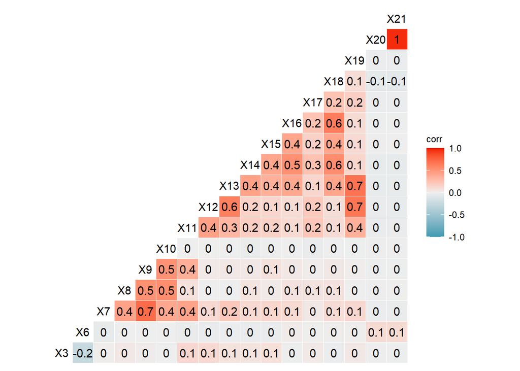

```r
GGally::ggcorr(quan_var, name = "corr", label = T)
```

```r
diag(solve(cor))
```

```
##         3         6         7         8         9        10        11        12
##  1.114663  1.087554  2.380131  1.675573  2.730450  1.700751  1.787804  2.299574
##        13        14        15        16        17        18        19        20
##  3.320140  1.764527  1.373716  1.917640  1.209643  2.028954  2.565907 14.672077
##        21
## 14.677267
```

```r
set.seed(2021)
idx <- sample(1:nrow(data), 10000)
dat <- data[idx,]
dim(dat)
```

```
## [1] 10000    22
```

- 129487명의 고객 데이터에서, 10000명의 랜덤 추출한 데이터를 사용

```r
Fullmod = glm(Satisfaction ~ ., dat = dat[,-21], family = binomial(link = "logit"))
backward <- step(Fullmod, direction = "backward") ; formula(backward)
```

- ‘출발 지연 시간’을 제외한 모든 설명변수를 포함한 완전모형에서 step()함수의 후진 소거법을 적용하여 최저의 AIC값을 가지는 모형을 탐색한 결과, 완전모형과 동일한 모형을 얻을 수 있었다.
- 이에 따라 본 분석에서는 완전모형을 적합하기로 결정하였다.

### 모형 적합

```r
summary(Fullmod)
```

```
##
## Call:
## glm(formula = Satisfaction ~ ., family = binomial(link = "logit"),
##     data = dat[, -21])
##
## Deviance Residuals:
##     Min       1Q   Median       3Q      Max
## -2.8028  -0.5798   0.2216   0.5267   3.6043
##
## Coefficients:
##                                 Estimate Std. Error z value Pr(>|z|)
## (Intercept)                   -6.829e+00  2.277e-01 -29.991  < 2e-16 ***
## GenderMale                    -9.560e-01  5.853e-02 -16.332  < 2e-16 ***
## Customer.TypeLoyal Customer    2.003e+00  8.900e-02  22.507  < 2e-16 ***
## Age                           -9.378e-03  2.051e-03  -4.572 4.83e-06 ***
## Type.of.TravelPersonal Travel -7.245e-01  8.332e-02  -8.695  < 2e-16 ***
## ClassEco                      -7.364e-01  7.531e-02  -9.779  < 2e-16 ***
## ClassEco Plus                 -6.683e-01  1.180e-01  -5.662 1.49e-08 ***
## Flight.Distance               -1.105e-04  3.044e-05  -3.631 0.000283 ***
## Seat.comfort                   3.054e-01  3.223e-02   9.474  < 2e-16 ***
## Dep.Arr.time.convenient       -2.448e-01  2.471e-02  -9.904  < 2e-16 ***
## Food.and.drink                -1.514e-01  3.313e-02  -4.569 4.91e-06 ***
## Gate.location                  1.427e-01  2.775e-02   5.142 2.71e-07 ***
## Inflight.entertainment         6.421e-01  2.905e-02  22.103  < 2e-16 ***
## Online.support                 5.380e-02  3.227e-02   1.667 0.095556 .
## Ease.of.Online.booking         2.061e-01  3.852e-02   5.350 8.80e-08 ***
## On.board.service               3.228e-01  3.010e-02  10.723  < 2e-16 ***
## Leg.room.service               2.132e-01  2.481e-02   8.594  < 2e-16 ***
## Baggage.handling               1.192e-01  3.248e-02   3.671 0.000242 ***
## Checkin.service                3.043e-01  2.466e-02  12.343  < 2e-16 ***
## Cleanliness                    5.587e-02  3.425e-02   1.631 0.102837
## Online.boarding                1.565e-01  3.389e-02   4.617 3.89e-06 ***
## Arrival.Delay                 -4.410e-03  8.100e-04  -5.445 5.17e-08 ***
## ---
## Signif. codes:  0 '***' 0.001 '**' 0.01 '*' 0.05 '.' 0.1 ' ' 1
##
## (Dispersion parameter for binomial family taken to be 1)
##
##     Null deviance: 13739.5  on 9999  degrees of freedom
## Residual deviance:  7822.3  on 9978  degrees of freedom
## AIC: 7866.3
##
## Number of Fisher Scoring iterations: 5
```

```r
qchisq(0.95, 9978)
```

```
## [1] 10211.49
```

- 다만, 데이터가 10000 X 21 의 차원을 가진 크기가 큰 데이터라는 점을 고려하였을 때, 위 결과의 낮은 P-값들과 그에 따른 통계적 유의성은 데이터의 크기 때문일 수도 있다는 점을 인지해야 된다.

### 오즈비 계산 및 회귀 계수 해석

|  | round(exp(Fullmod$coefficients), 4) |
| --- | --- |
| (Intercept) | 0.0011 |
| GenderMale | 0.3844 |
| Customer.TypeLoyal Customer | 7.4125 |
| Age | 0.9907 |
| Type.of.TravelPersonal Travel | 0.4846 |
| ClassEco | 0.4788 |
| ClassEco Plus | 0.5126 |
| Flight.Distance | 0.9999 |
| Seat.comfort | 1.3571 |
| Dep.Arr.time.convenient | 0.7829 |
| Food.and.drink | 0.8595 |
| Gate.location | 1.1534 |
| Inflight.entertainment | 1.9005 |
| Online.support | 1.0553 |
| Ease.of.Online.booking | 1.2289 |
| On.board.service | 1.3810 |
| Leg.room.service | 1.2377 |
| Baggage.handling | 1.1266 |
| Checkin.service | 1.3557 |
| Cleanliness | 1.0575 |
| Online.boarding | 1.1694 |
| Arrival.Delay | 0.9956 |

### 모형의 예측값은, 전체 데이터에 대하여 얼마나 높은 정확도를 보이는가?

- 분석에서 적합한 로지스틱 모형의 평가를 위하여, 모형을 바탕으로 각 고객이 항공사의 서비스에 만족할 확률()을 예측하여 실제 고객의 응답결과와 대조하면 예측 정확도, 즉 ‘정분류율’을 계산할 수 있다.
- (단 pred()함수의 type을 “response”로 설정하여 계산된 각각의 예측값()들을 반올림하여, 0.5이상이라면 1(만족), 그렇지 않다면 0이라는 가정이 필요하다.)

```r
pred <- predict(Fullmod, newdata = data, type = "response")
pred1 <- as.factor(ifelse(pred < 0.5, 0, 1))
(CM <- table(pred1, data$Satisfaction))
```

```
##
## pred1     0     1
##     0 47602 10347
##     1 11003 60535
```

```r
mean(pred1 == data$Satisfaction)
```

```
## [1] 0.8351186
```

## 3. 결론

### 가능한 추가 분석의 방향

- 다른 국가 및 항공사 데이터의 수집과 분석을 통한, 본 프로젝트와의 비교.
- 2015년만이 아닌 최근 데이터의 수집과 분석을 통한, 본 프로젝트와의 비교.
- 전체 데이터를 사용하는 것이 아닌, 훈련데이터/평가데이터의 분할 및 추출을 통한 교차 검증(Cross Validation)과 그에 따른 예측 정확도 개선.
- 이외의 예측·분류 알고리즘(예 : 서포트 벡터 머신, 부스팅, 의사결정나무 등)들을 적용하여 로지스틱 회귀와 비교.